# R Primer

### Geom (add a geom layer)

- This is how the data will be visualized -`geometric objects` to show up on the plot.
- This is done using `geom_*()` where `*` is one of the several geoms that we can plot.
- When plotting with `ggplot2`, you specify different parts of the plot, and add them together using the `+` operator.
- For a scatter plot, use `geom_point()` and `+` to the plot above.

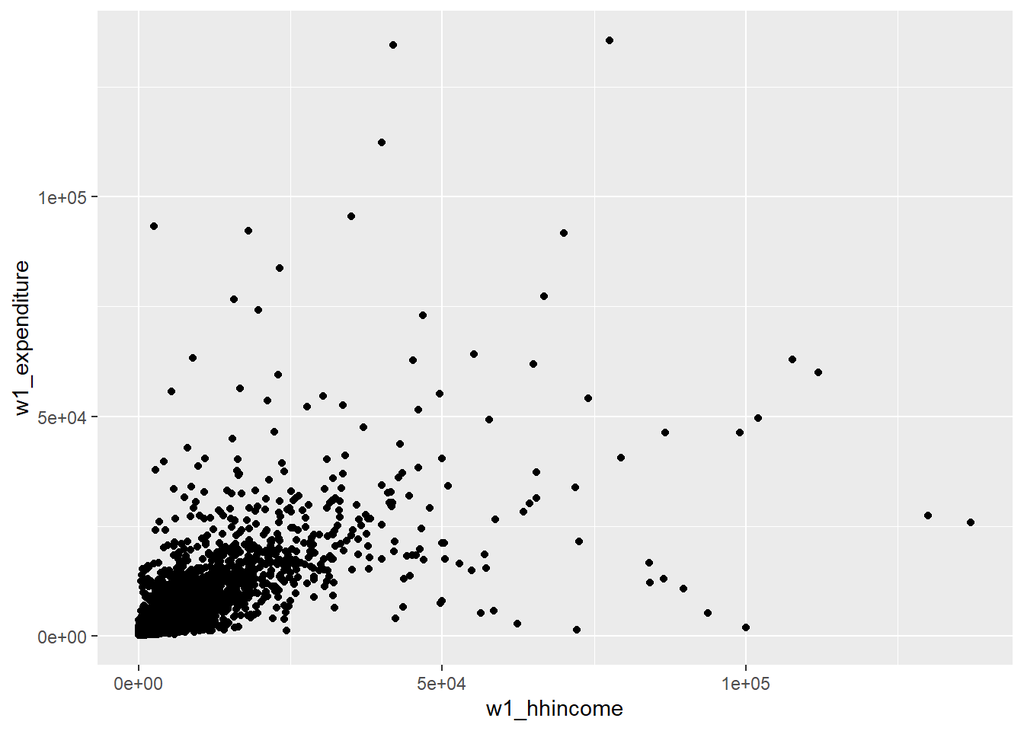

```r
ggplot(data = inc_exp, aes(x=w1_hhincome, y=w1_expenditure)) +
  geom_point()
```

- The bare minimum required to create a plot in ggplot2 are: `dataset`, `X` and `Y` variables and the `geometric` shape to represent data.

#### Example geometric shapes

- `ggplot2` supports a number of different types of geoms that include:
  - `geom_point` for drawing individual points (e.g., a scatter plot)
  - `geom_line` for drawing lines (e.g., for a line charts)
  - `geom_smooth` for drawing smoothed lines (e.g., for simple trends or approximations)
  - `geom_bar` for drawing bars (e.g., for bar charts)
  - `geom_histogram` for drawing binned values (e.g. a histogram)
  - `geom_polygon` for drawing arbitrary shapes
  - `geom_boxplot`: boxes-and-whiskers
  - `geom_errorbar`: T-shaped error bars
  - `geom_ribbon`: bands spanning y-values across a range of x-values
- Each of these geometries will leverage the aesthetic mappings supplied although the specific visual properties that the data will map to will vary.
- More customisation can be done to plot the variables on the log scale, add units, add title amd axis labels, and change the background theme.

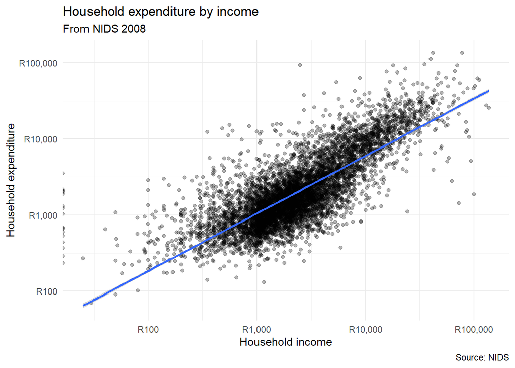

```r
p <- ggplot(data = inc_exp, aes(x = w1_hhincome, y = w1_expenditure)) +
  geom_point(alpha=0.3) +  # transparency
  geom_smooth(method="lm") + # smooth distribution - linear model
  scale_x_log10(labels = scales::dollar_format(suffix = "", prefix = "R")) + #log scale
  scale_y_log10(labels = scales::dollar_format(suffix = "", prefix = "R")) + #log scale
  labs(title = "Household expenditure by income", #title
       subtitle = "From NIDS 2008", # subtitle
       x = "Household income", # x-axis title
       y = "Household expenditure", # y-axis title
       caption="Source: NIDS") + # caption
  theme_minimal() # change theme
p
```

### Histogram

The `geom` for a histogram is `geom_histogram`. We again plot the histogram for household income:

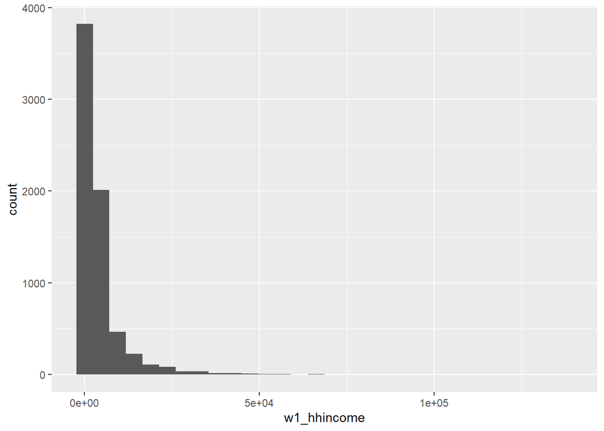

```r
ggplot(inc_exp, aes(w1_hhincome))+
  geom_histogram()
```

We can improve this by dropping some outlier observations

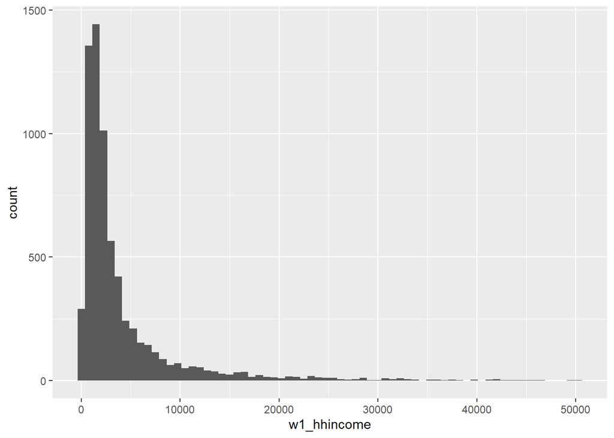

```r
ggplot(inc_exp %>% filter(w1_hhincome<50000), aes(w1_hhincome))+
  geom_histogram(binwidth = 750)
```

Or plot on a log scale

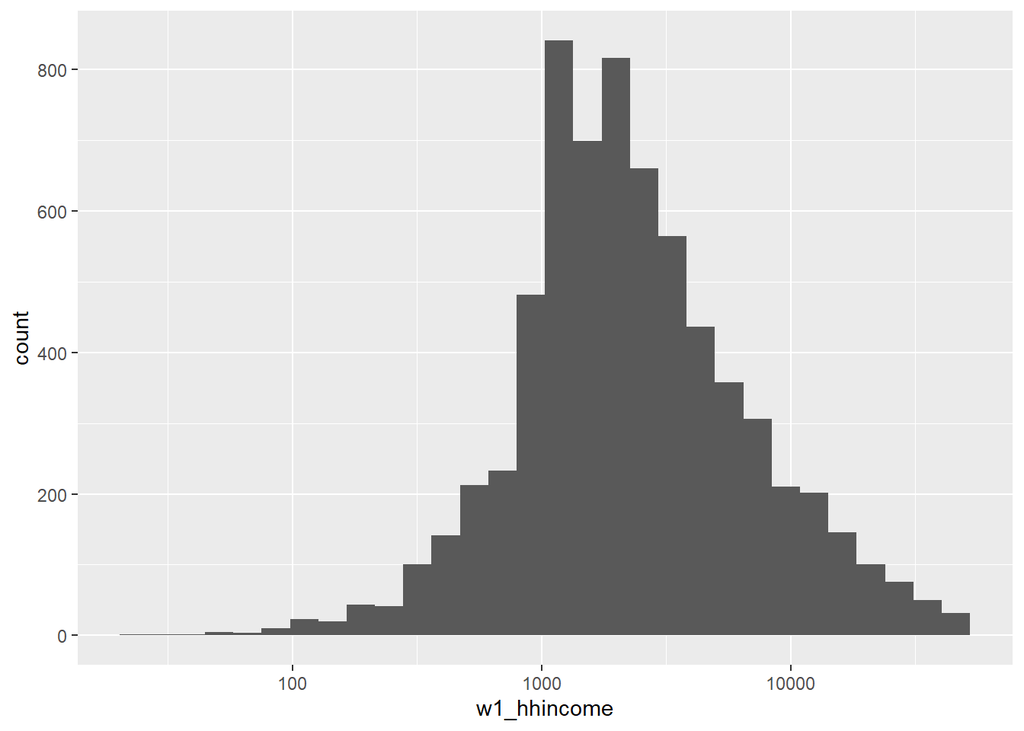

```r
ggplot(inc_exp %>% filter(w1_hhincome<50000), aes(w1_hhincome))+
  geom_histogram()+
  scale_x_log10()
```

### Boxplot

The `geom` for a boxplot is `geom_boxplot`. We again plot the boxplot for household expenditure by population group of the household head. This population group variable is in the `nids_df`.

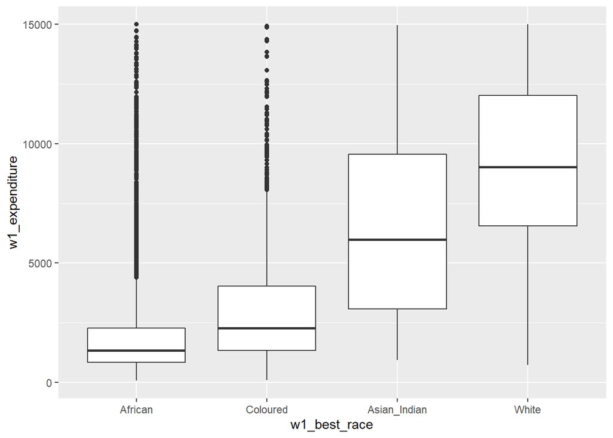

```r
inc_exp %>% filter(w1_expenditure<15000) %>%
  ggplot(aes(x = w1_best_race, y = w1_expenditure))+
  geom_boxplot()
```

### Aesthetics - shapes

We plot household expenditure against household income with different shapes by population group

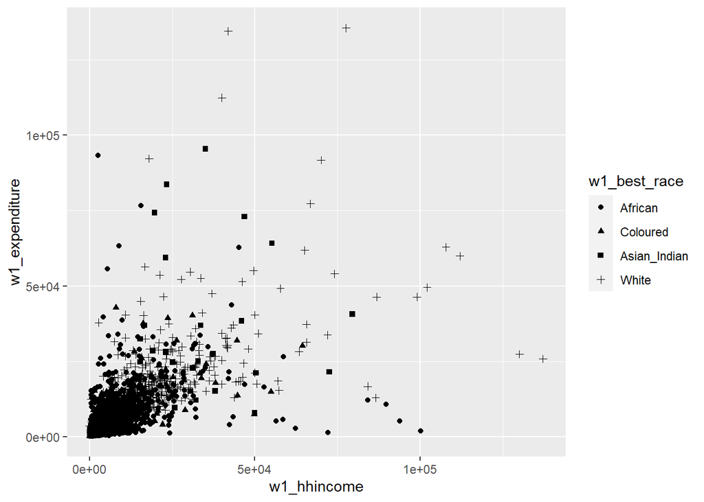

```r
ggplot(data = inc_exp, aes(x=w1_hhincome, y=w1_expenditure, shape = w1_best_race)) +
  geom_point()
```

### Aesthetics - color

We plot household expenditure against household income with different colour by race

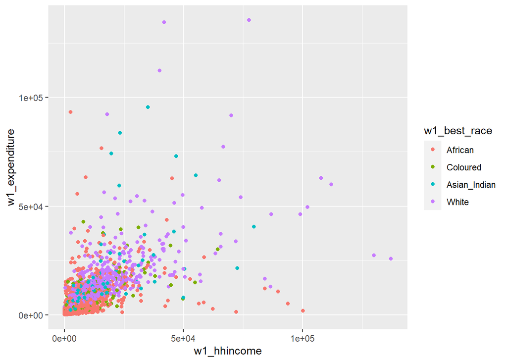

```r
ggplot(data = inc_exp, aes(x=w1_hhincome, y=w1_expenditure, color = w1_best_race )) +
  geom_point()
```

This also applies to shapes

### Facet

- Split data into subsets and plot each subset on a different panel
- The faceting functions are:
  - `facet_wrap` - wraps a 1d sequence of panels into 2d and
  - `facet_grid` - forms a matrix of panels defined by row and column faceting variables.

**facet_wrap**

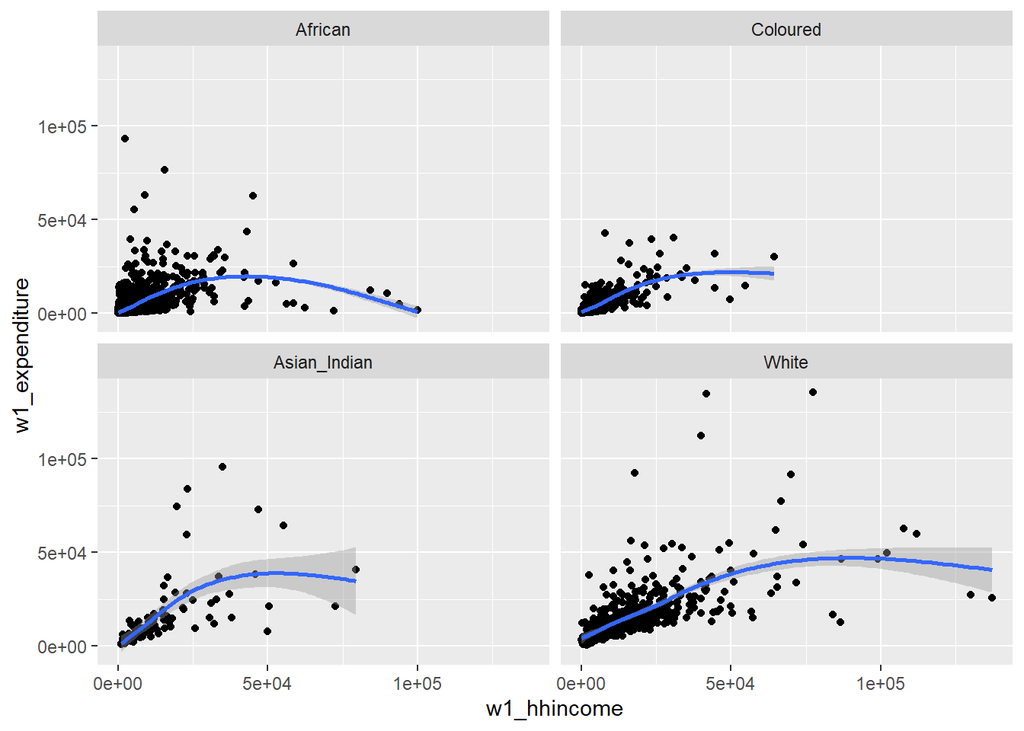

```r
ggplot(inc_exp, aes(x = w1_hhincome, y=w1_expenditure)) +
  geom_point() +
  geom_smooth() +
  facet_wrap(~w1_best_race)
```

Any other graphics can similarly be plotted.

### Saving plots to files

- use `ggsave()`.
- The last plot displayed is saved by default, but we can also save a plot stored to an R object.
- `ggsave` also guesses the type of graphics device from the extension. Available devices include `eps/ps`, `tex` (pictex), `pdf`, `jpeg`, `tiff`, `png`, `bmp`, `svg` and `wmf`. The size of the image can be specified as well.
- To save `p` to the `figures` subfolder, type the folowing:

```r
#save last displayed plot as pdf
ggsave(plot = p, "./figures/incVexp.pdf")
#save plot stored in "p" as png and resize
ggsave(plot = p, "./figures/incVexp.png", width=10, height=10, units="in")
#?ggsave
```

# Spatial data

**Spatial data** represents the location, size and shape of an object on the Earth.

## Types of spatial data

There are two fundamental models for representing geospatial data, i.e. **vector** and **raster**. **Vector data** is based on coordinates (e.g. longitude and latitude) of points on the earth’s surface, which can be connected to make lines and polygons. **Rasta data** is based on pixels or gridded cells to represent surface features.

This short introduction introduces tools for handling **vector data** in R. Examples of vector data are:

**Point(s)** - discrete data points (e.g. house, point of interest, e.t.c.)

**Line(s)** - connected points (e.g. roads, electricity grid, etc)

**Polygon(s)** - closed boundaries (administrative city, lake, forest, etc)

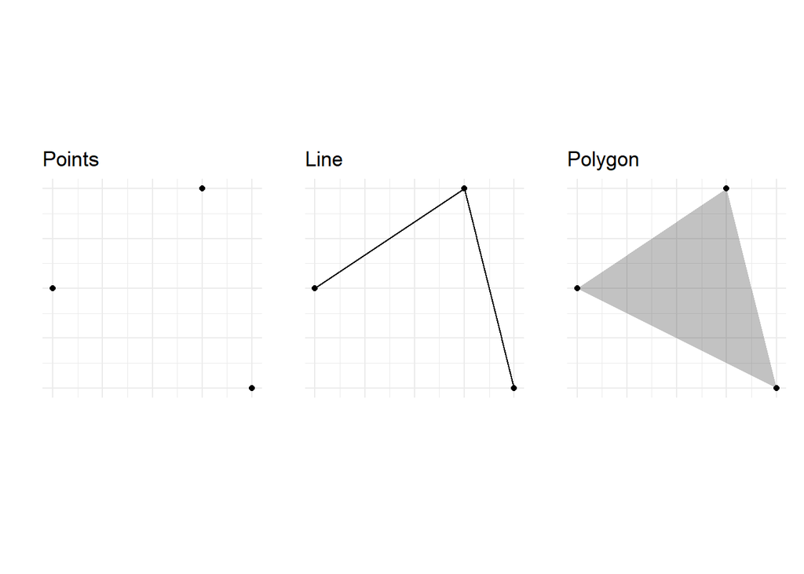

## Common vector spatial data formats

The following are some of the common formats in which spatial data is stored:

**.shp** (shapefile - at least 3 files - **.shp**, **.shx**, **.dbf** plus **.prj**, **.shp.xml**)

**.geojson** (web-based mapping)

**.csv** (general format that can be opened on most platforms)

## Tools used to process spatial data

- ArcGIS (Esri)
- QGIS (Quantum GIS)
- GRASS GIS
- GeoDa
- **R**

## Why R for spatial data analysis

- R is **free and open source** which makes it cheaper to get started (how about other FOSS for GIS)
- The R command-line interface facilitates the **automation** of repetitive task (some of the GUI software share an API with python)
- The R command-line interface enables a **transparent** and **reproducible** workflow
- The command-line interface is also **flexible** to customize and extent the analysis to one’s liking.
- R offers a large ecosystem of libraries/packages to perform various operations in the data analysis cycle (data access, data cleaning, data analysis, visualisation and report generation). Therefore, there is usually no need to do your analysis in one software and bring results into a GIS software.

Check the **Introduction** in Lovelace, Nowosad, and Muenchow (2019) for more on good reasons to use R for spatial data analysis.

## Intergration with other GIS software

- It is possible to integrate R with other mature GIS software (most of these are GUI interfaces) and have access to functionality that is not yet available in R. Check Lovelace, Nowosad, and Muenchow (2019) (also freely available online on https://geocompr.robinlovelace.net/) on wrapper packages for QGIS, GRASS, SAGA and more, and the [R – ArcGIS Community](https://r.esri.com/) for packages to connect with ArcGIS.

## The `sf` library

**Simple features** is a set of standards for geospatial data. The `sf` library (Pebesma 2018) is an implementation of simple features in R.

An `sf` object in R is based on the `data.frame` or tibble: it has multiple columns with different variables (often called attributes), as well as a geometry column, containing the spatial vector geometry. Each row represents one feature. It also contains information about the coordinate reference system used for the geometries. The `sf` package is compatible with `tidyverse` packages like `dplyr`, `ggplot`, e.t.c.

The `sf` package offers many methods and functions to operate on spatial data. Most `sf` function names, particularly those related to spatial data processing and analysis, start with `st_`, for *spatial type*. Typical application of the `sf` functions includes *reading, manipulating and writing of sets of features, with attributes and geometries*.

To access `sf` functions, we first need load the `sf` package into our workspace:

```r
# load packages
library(sf)
```

- We import shapefiles using the `st_read` function or its alias, `read_sf`
- The layer specification of the `layer` argument varies by driver
- We import the SA province shapefile as follows:

```r
sa_prov<-st_read(dsn="./PR_SA_2011", layer="PR_SA_2011") #no extension
#sa_prov<-st_read(dsn="./shapefiles/PR_SA_2011/PR_SA_2011.shp") #extension
```

```r
class(sa_prov)
```

```
## [1] "sf"         "data.frame"
```

- `sa_prov` is of class `sf` and `data.frame`.

```r
sa_prov
```

```
## Simple feature collection with 9 features and 7 fields
## Geometry type: MULTIPOLYGON
## Dimension:     XY
## Bounding box:  xmin: 16.45191 ymin: -34.83417 xmax: 32.94498 ymax: -22.12503
## Geodetic CRS:  WGS 84
##   PR_MDB_C PR_CODE PR_CODE_st       PR_NAME ALBERS_ARE SHAPE_Leng SHAPE_Area
## 1       EC       2          2  Eastern Cape  168965.97   28.20638  16.154667
## 2       FS       4          4    Free State  129825.16   24.24960  11.979428
## 3       GT       7          7       Gauteng   18178.31   10.96706   1.640382
## 4      KZN       5          5 KwaZulu-Natal   94361.32   19.02478   8.715379
## 5      LIM       9          9       Limpopo  125753.97   21.85956  11.141413
## 6       MP       8          8    Mpumalanga   76494.69   23.65078   6.889972
## 7       NW       6          6    North West  104881.68   26.09149   9.477825
## 8       NC       3          3 Northern Cape  372889.41   48.00840  34.691554
## 9       WC       1          1  Western Cape  129462.19   38.08598  12.494680
##                         geometry
## 1 MULTIPOLYGON (((29.02187 -3...
## 2 MULTIPOLYGON (((27.97704 -2...
## 3 MULTIPOLYGON (((28.75833 -2...
## 4 MULTIPOLYGON (((30.51695 -3...
## 5 MULTIPOLYGON (((29.65523 -2...
## 6 MULTIPOLYGON (((31.80952 -2...
## 7 MULTIPOLYGON (((26.4189 -24...
## 8 MULTIPOLYGON (((20.04457 -2...
## 9 MULTIPOLYGON (((18.15928 -3...
```

- the `sf` [document](https://r-spatial.github.io/sf/articles/sf1.html) describe the three classes used to represent simple features which are:
  - `sf`, the table (`data.frame`) with feature attributes and feature geometries, which contains
  - `sfc`, the list-column with the geometries for each feature (record), which is composed of
  - `sfg`, the feature geometry of an individual simple feature.
- `sf` has its own geometry types

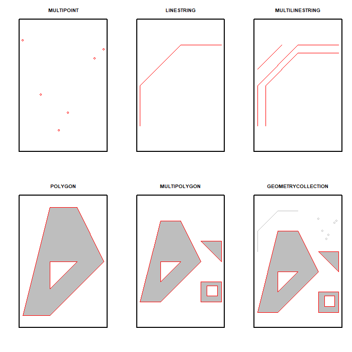

- see also the [`sf`](https://r-spatial.github.io/sf/articles/sf1.html) website
- `sf` has its own plot function.
- We can use the `st_geometry` function to get the geometry from an `sf` object and plot:

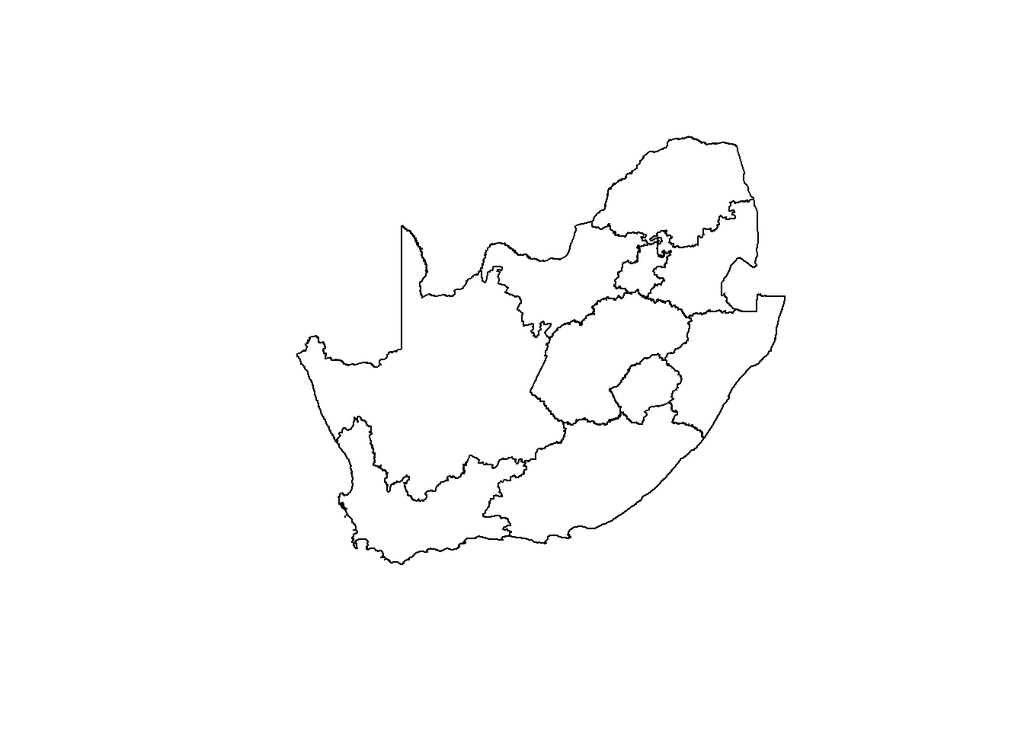

```r
# pull just the geometry
sa_prov %>% st_geometry() %>% plot()
```

```r
#plot(st_geometry(sa_prov))
```

Or you can plot a specific attribute, e.g., shapefile length:

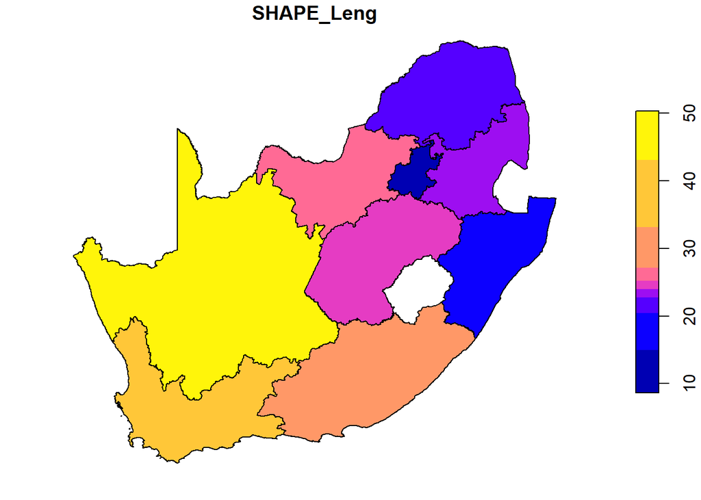

```r
plot(sa_prov["SHAPE_Leng"])
```

The plotting above was just a teaser, more advanced features will be covered tomorrow, and we end here.

Thank you

# Further reading

1. [Geocomputation with R](https://geocompr.robinlovelace.net/) (Lovelace, Nowosad, and Muenchow 2019): An excellent, free online resource on working with geospatial raster and vector data in R.
2. [Spatial Data Science](https://keen-swartz-3146c4.netlify.app/) (Pebesma and Bivand 2022): Still work in progress but an excellent online book on working with spatial data in R.

# References

Lovelace, Robin, Jakub Nowosad, and Jannes Muenchow. 2019. *Geocomputation with R*. CRC Press.

Pebesma, Edzer. 2018. “Simple Features for R: Standardized Support for Spatial Vector Data.” *The R Journal* 10 (1): 439–46. https://doi.org/10.32614/RJ-2018-009.

Pebesma, Edzer, and Roger Bivand. 2022. *Spatial Data Science*.

Wickham, Hadley. 2016. *Ggplot2: Elegant Graphics for Data Analysis*. Springer.

Wickham, Hadley, and Garrett Grolemund. 2016. *R for Data Science: Import, Tidy, Transform, Visualize, and Model Data*. " O’Reilly Media, Inc.".

Wilkinson, Leland. 2012. “The Grammar of Graphics.” In *Handbook of Computational Statistics*, 375–414. Springer.